# Sonja Next Word

Author: Sonja Sahebzad  
September 25, 2026

SONJA PROJECTS

A small assist for  
your next sentence.

A responsive English word-completion product.  
Built in R. Published with Shiny. Measured honestly.

[Open the live app](https://sonjasahebzad.shinyapps.io/sonja-next-word/)

Five slides. Use the navigation controls or arrow keys.

### Common patterns, compact delivery

### Learn from real writing

3.21 million training lines from the official English blogs, news and Twitter corpus.

### Combine short and long patterns

Up to four recent words guide a five-gram model. Kneser-Ney smoothing blends shorter patterns when evidence is limited.

### Keep only useful continuations

Pruned vocabulary and followers reduce memory. Sparse scoring preserves the compact model’s exact top suggestions.

**19.2 MiB**compressed model**50,000**possible next words

CPU only.  
No external prediction API.  
Model loaded once per process.

### Type. Predict. Keep writing.

1. Enter an English phrase.
2. Add a space for automatic suggestions, or select **Predict next word**.
3. Select a suggestion to append it, or keep typing.

Suggestions refresh as you continue. A fallback keeps unfamiliar contexts usable.

The Results tab explains measured quality. The How to use tab documents the product.

[Try the live app](https://sonjasahebzad.shinyapps.io/sonja-next-word/)

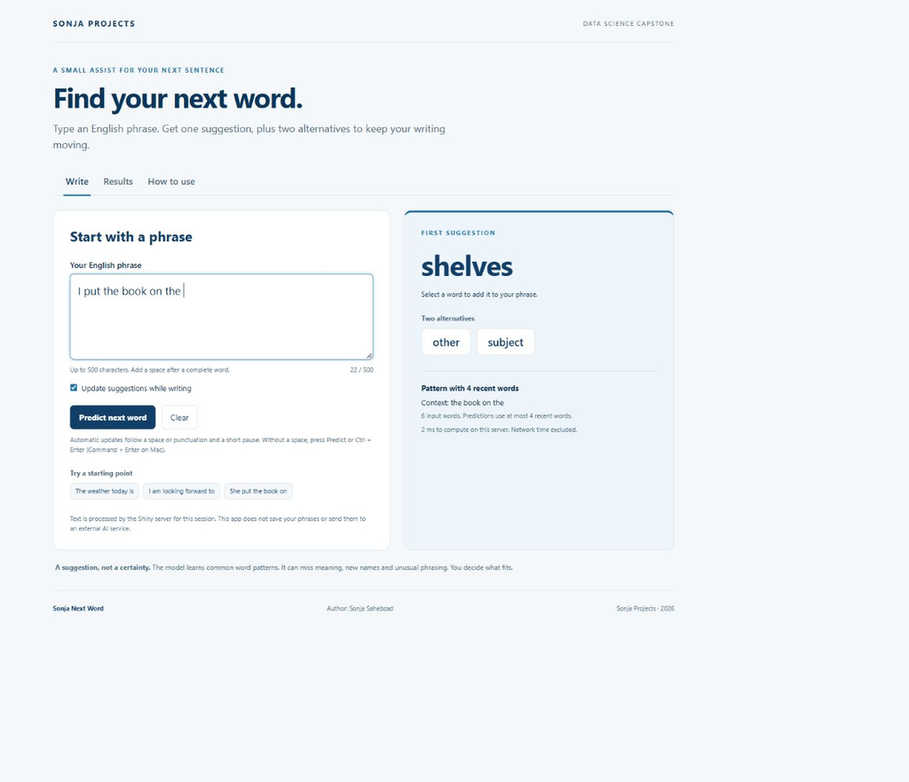

### Performance of the deployed model

900 reserved examples. 300 each from blogs, news and Twitter.  
Chosen on 600 separate development cases, then frozen before testing.

**17.0%**

### First suggestion correct

153 / 900  
95% interval 14.7% to 19.6%

**28.6%**

### Correct within three

257 / 900  
95% interval 25.7% to 31.6%

**0.58 ms**

### Median computation

95th percentile 0.83 ms  
3,000 warm local calls.  
Network and typing delay excluded.

900 / 900 cases received a suggestion. This is availability, not 100% accuracy.

Approximate Wilson intervals describe test uncertainty. Individual confidence is not calibrated. Timing: 600 development inputs, five rounds; exact indexed predictions.

### A deployable foundation, with a clear next step

### Value delivered

A working web product with fast local computation, clickable suggestions, readable documentation and reproducible evidence.

### Limits made visible

Short context can miss sentence meaning. New names and rare phrases remain difficult. A modest profanity blocklist is not a complete filter.

### Next investment

Compare longer context under the same hosting budget. Calibrate on separate data. Measure suggestion acceptance with users.

[Explore Sonja Next Word](https://sonjasahebzad.shinyapps.io/sonja-next-word/)

Sources: [Coursera SwiftKey corpus](https://d396qusza40orc.cloudfront.net/dsscapstone/dataset/Coursera-SwiftKey.zip); [Chen & Goodman, 1996](https://aclanthology.org/P96-1041/); [Posit Shiny](https://shiny.posit.co/).  
[Code, test protocol, case metrics and full report](https://github.com/Sonja242/data-science-capstone-swiftkey/tree/main/final_project). Author: Sonja Sahebzad.